# S2 T2: Estructura de una Matriu

A continuación, utilice esta máscara para indexar en la matriz de números original.

Esto hace que la matriz pierda su forma original,

reduciéndola a una dimensión, pero todavía obtenga los datos que está buscando.

```python
# para ello indexando a la matriz la mascara
Mij3 = Mij2.copy()
Mij4 = Mij2.copy()
Mij3 [mascara]
```

```
array([-28.,   8., -24., -16.,  20.,  -8.,  20.,  -8.])
```

- Ejercicio 8

Cargad cualquier imagen (jpg, png..) con Matplotlib. Date cuenta de que las imágenes RGB (Red, Green, Blue) son realmente sólo

anchuras × alturas × 3 matrices (tres canales Rojo, Verde y Azul), una por cada color de números enteros int8,

manipule estos bytes y vuelva a utilizar Matplotlib para guardar la imagen modificada una vez haya terminado.

Ayuda:Importe, import matplotlib.image as mpimg. estudie el método de mpimg.imread(()

Muéstrame a ver qué ocurre cuando eliminamos el canal G Verde o B Azul.

Deberías utilizar la indexación para seleccionar el canal que desea anular.

Utilizar el método, mpimg.imsave () de la librería importada, para guardar

las imágenes modificadas y que deberá subir a su repositorio en github.

```
(638, 1200, 4)
```

[figure not shown]

```python
import matplotlib.image as mpimg
import matplotlib.pyplot as plt
img = mpimg.imread("goku.png")
plt.imshow(img)
plt.title('Imagen')
plt.axis('off')
print ( img.shape)# para ver la forma de la array


plt.show()



mpimg.imsave("img.png", img)
```

[figure not shown]

[figure not shown]

[figure not shown]

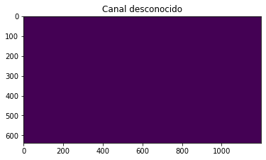

```python
# vemos que tiene cuatro canales de color en vez de 3
#vamos a manipularlos.

plt.imshow(img[:,:,0])
plt.title("Canal Rojo")
plt.show()
plt.imshow(img[:,:,1])
plt.title("Canal Verde")
plt.show()
plt.imshow(img[:,:,2])
plt.title("Canal Azul")
plt.show()
plt.imshow(img[:,:,3])
plt.title("Canal desconocido")
plt.show()
```

```python
# vamos a desmontar la array en los cuatro canales.
col0 = img[:,:,0].copy()
col1 = img[:,:,1].copy()
col2 = img[:,:,2].copy()
col3 = img[:,:,3].copy()

# miremos como es este último canal, el desconocido
print (col3)
```

```
[[1. 1. 1. ... 1. 1. 1.]
 [1. 1. 1. ... 1. 1. 1.]
 [1. 1. 1. ... 1. 1. 1.]
 ...
 [1. 1. 1. ... 1. 1. 1.]
 [1. 1. 1. ... 1. 1. 1.]
 [1. 1. 1. ... 1. 1. 1.]]
```

[figure not shown]

[figure not shown]

```python
# vemos que es uniforme, probemos que pasa si quitamos esta capa
colprueba= img[:,:,0:3].copy()
plt.imshow(colprueba)
plt.title("sin canal 3")
plt.show()

# y comparamos con la imagen normal
plt.imshow(img)
plt.title("imagen sin filtro")
plt.show()
```

```python
# observamos que son idénticas
```

[figure not shown]

```python
# probemos de filtrar el rojo
zeros = np.zeros ((638,1200 ))
imgnotR= np.dstack ((col1, col2, zeros))
plt.imshow(imgnotR)
plt.title("sin canal 0")
plt.show()

mpimg.imsave("imgnotR.png", imgnotR)
```

[figure not shown]

```python
# probemos de filtrar el verde
zeros = np.zeros ((638,1200 ))
imgnotG= np.dstack ((col0, col2, zeros))
plt.imshow(imgnotG)
plt.title("sin canal 1")
plt.show()
mpimg.imsave("imgnotG.png", imgnotG)
```

[figure not shown]

```python
# probemos de filtrar el azul
zeros = np.zeros ((638,1200 ))
imgnotB= np.dstack ((col0, col1, zeros))
plt.imshow(imgnotB)
plt.title("sin canal 2")
plt.show()
mpimg.imsave("imgnotB.png", imgnotB)
```

[figure not shown]

```python
# vamos a pasarlo a grises.
R,G,B = col0,col1,col2
imag_grey = 0.2989 * R + 0.5870 * G + 0.1140 * B # donde el vector (0.2989, 0.5870, 0.114) es el color gris.
plt.imshow(imag_grey, cmap = "gray") # ponemos un mapa de colores de grises
plt.title("gris")
plt.show()
```